# Series Temporales

Maria Ruiz Teixidor, Enrique Macip Belmonte

15/7/2020

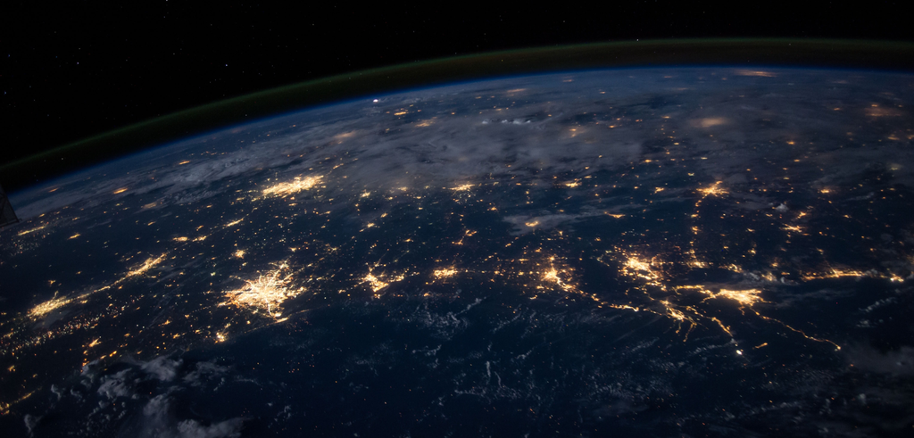

# Introducción

Los datos de este apartado de la práctica son datos de la demanda b.c en España. Es decir, la energía que, una vez de toda la generada, se ha vendido, comprado o utilizado para bombero, la que queda disponible para proveer a la población de España.

Ésta ha sido obtenido a través de la API de Red Eléctrica (REE). Se ha adjuntado el fichero con el que se han obtenido los datos. Éstos van desde enero 2018 hasta febrero 2020 para que no coincida el periodo que se quiere predecir con el COVID19 ya que dificultaría la práctica.

```r
setwd("~/Escritorio/MASTER/CUATRI3/MACHINE_LEARNING2/PRACTICA/ML2/Series Temporales")
df_ree <- read.csv("~/Escritorio/MASTER/CUATRI3/MACHINE_LEARNING2/PRACTICA/ML2/Series Temporales/ree.csv")
```

```r
df_ree$id <- NULL
df_ree$date = substr(df_ree$datetime,1,10)

mape <- function(actual,pred){
  mape <- mean(abs((actual - pred)/actual))*100
  return (mape)}

# FUNCIÓN MY RESIDUALS

my_tsresiduals <- function(data, ...){
  if(!fabletools::is_mable(data)){
    abort("gg_tsresiduals() must be used with a mable containing only one model.")
  }

  data <- stats::residuals(data)
  if(n_keys(data) > 1){
    abort("gg_tsresiduals() must be used with a mable containing only one model.")
  }

  gg_tsdisplay(data, !!sym(".resid"), plot_type = "partial", ...)
}

#' @export
`+.gg_tsensemble` <- function(e1, e2){
  e1[[1]] <- e1[[1]] + e2
  e1
}

#' @export
print.gg_tsensemble <- function(x, ...){
  print(x[[1]], vp = grid::viewport(layout.pos.row = c(1, 1), layout.pos.col = c(1, 2)))
  print(x[[2]], vp = grid::viewport(layout.pos.row = 2, layout.pos.col = 1))
  print(x[[3]], vp = grid::viewport(layout.pos.row = 2, layout.pos.col = 2))
}
```

# Lectura de datos

```r
df_demanda <- df_ree %>%
  filter(subcategory == "Demanda en b.c.")

df_demanda$datetime <- as.POSIXct(df_demanda$datetime)
df_demanda$date <- as.Date(as.character(df_demanda$datetime)) #, format="%d/%m/%Y", origin = "2018-01-01"
```

```r
# dividir TRAIN - TEST
# Train: enero 2018- enero 2020
df_demanda_train = df_demanda[df_demanda$date < '2020-02-01',]
# Test: febrero 2020
df_demanda_test = df_demanda[(df_demanda$date > '2020-01-31') & (df_demanda$date <= '2020-02-10'),] #2020-03-01

df_demanda = df_demanda[(df_demanda$date < '2020-02-10'),] ##2020-03-01
```

# Análisis previo series temporales

```r
# Transform into a tibble object
df_demanda_train <- df_demanda_train %>%
  as_tsibble(index = date) #key = c(energy), index = datetime

df_demanda_test <- df_demanda_test %>%
  as_tsibble(index = date) #key = c(energy), index = datetime# Descomposición clásica

df_demanda <- df_demanda %>%
  as_tsibble(index = date) #key = c(energy), index = datetime# Descomposición clásica
```

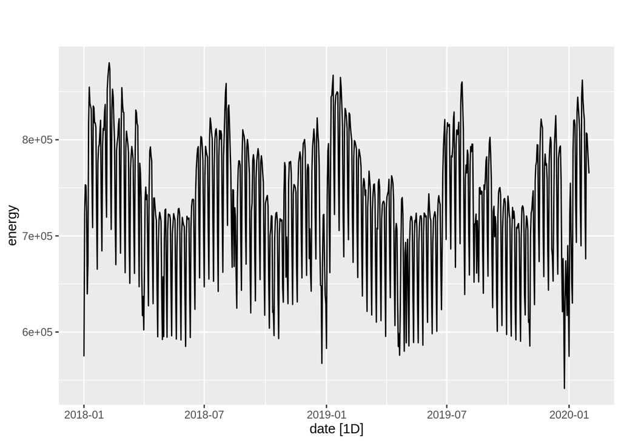

```r
# plot series temporales
df_demanda_train %>%
  autoplot(energy) +
  labs(title = "", subtitle = "")
```

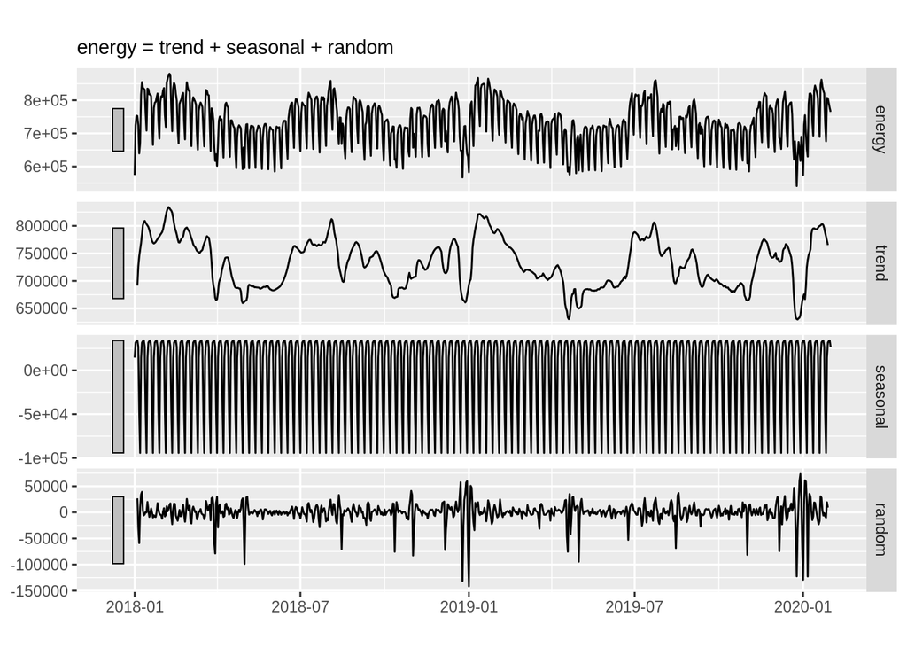

```r
#aditivo
df_demanda_train %>%
  model(classical_decomposition(energy, type = "additive")) %>%
  components() %>%
  autoplot() + xlab(" ") +
  ggtitle(" ")
```

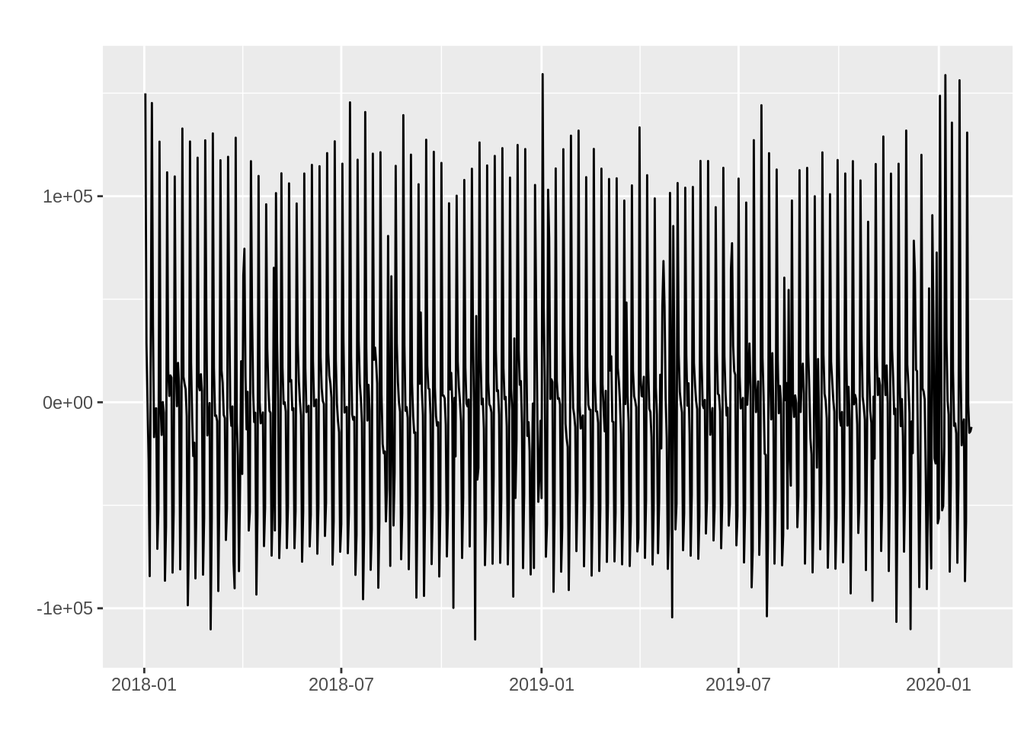

```r
# Diferenciación
# Se observa que tras la diferenciación la serie pierde la tendencia, siendo claramente estacionaria en media.
# yt = xt - x(t-1)
df_demanda_train %>% autoplot( difference(energy)) +
  xlab("  ") + ylab(" ") +
  ggtitle("  ")
```

```r
# Una forma de determinar más objetivamente si es necesario diferenciar es utilizar una prueba de raíz unitaria.
# En este contraste, la hipótesis nula es que los datos son estacionarios, y buscamos pruebas de que la hipótesis nula es falsa. En consecuencia, pequeños p-valores (por ejemplo, menos de 0,05) sugieren que es necesario diferenciar.
df_demanda_train %>%
  features(energy, unitroot_kpss)
```

```
## # A tibble: 1 x 2
##   kpss_stat kpss_pvalue
##       <dbl>       <dbl>
## 1     0.467      0.0491
```

```r
#El p-valor es menor que 0.05, lo que indica que la hipótesis nula es rechazada.

df_demanda_train %>%
  mutate(diff_close = difference(energy)) %>%
  features(diff_close, unitroot_kpss)
```

```
## # A tibble: 1 x 2
##   kpss_stat kpss_pvalue
##       <dbl>       <dbl>
## 1    0.0468         0.1
```

```r
#Comprobar si existen autocorrelaciones significaticas:
df_demanda_train %>%
  mutate(diff_close = difference(energy)) %>%
  features(diff_close, ljung_box, lag = 10)
```

```
## # A tibble: 1 x 2
##   lb_stat lb_pvalue
##     <dbl>     <dbl>
## 1    842.         0
```

# MODELOS

es posible utilizar las gráfica de ACF y PACF, para determinar los valores apropiados para p y q. Correlograma Gráfico en el que representamos los valores de la función de autocorrelación empírica r k contra los retardos k = 1, 2, … , M donde típicamente M ≪ N . Vemos que tiene muchos componentes significativas para algún retardo. df_demanda_train %>% ACF(difference(energy, 1)) %>% autoplot() Mejor observar el ACF y PACF sin la diferenciación primero

el pico significativo en el retardo 7 del ACF sugiere un componente MA(1) estacional Vemos que hay unos picos estacionales cada 7 días -> componente estacional. El pico significativo en el retardo 1 del ACF sugiere por lo menos una componente MA(2) no estacional

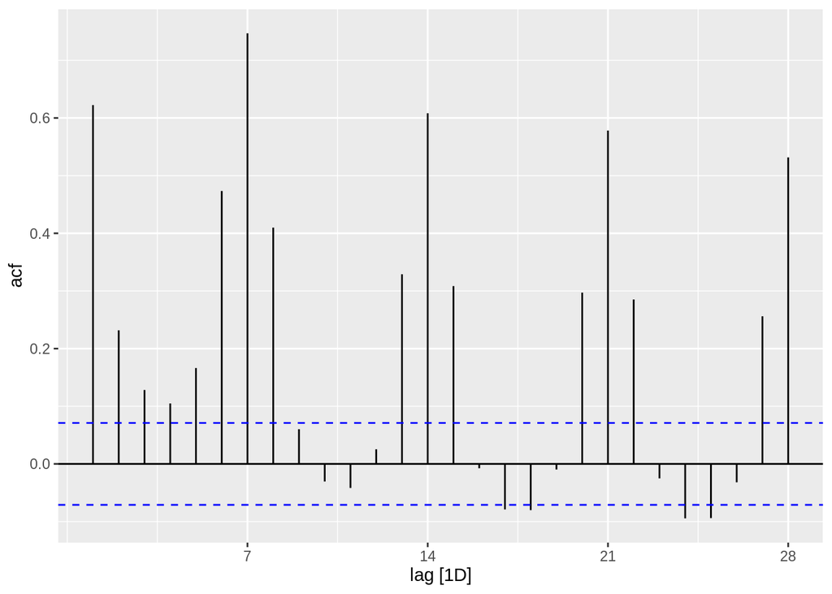

```r
df_demanda_train %>% ACF(energy) %>% autoplot()
```

### Autocorrelación parcial

correlación que resulta después de eliminar el efecto de cualquier correlación en retardos más cortos autocorrelación entre los instantes t y t + k condicionada a los valores que toma la serie en los instantes t + 1, t + 2, … , t + k − 1 .

Mejor observar el ACF y PACF sin la diferenciación primero Se continúa observando picos estacionales a los 7 días Sigue un comportamiento parecido al gráfico anterior: El pico significativo en el retardo 1 del ACF sugiere por lo menos una componente MA(2) no estacional un pico en la primera componente, sugiriendo una componente autoregresiva por lo menos de valor 1.

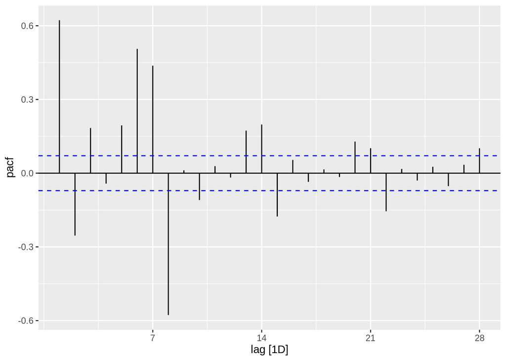

```r
df_demanda_train %>% PACF(energy) %>% autoplot()
```

```r
df_demanda1_diff <- difference(df_demanda_train$energy, 7)
```

# SARIMA

## Ajuste 1

```r
# Probamos ajustando un modelo con componentes de
fit <- df_demanda_train %>%
  model(arima = ARIMA(energy ~ pdq(0,0,2) + PDQ(0,0,2))) #pdq(0,0,2) + PDQ(0,0,2)
```

```r
report(fit)
```

```
## Series: energy
## Model: ARIMA(0,0,2)(0,0,2)[7] w/ mean
##
## Coefficients:
##          ma1     ma2    sma1    sma2   constant
##       0.8459  0.2550  0.6957  0.3656  731251.73
## s.e.  0.0340  0.0327  0.0352  0.0292    5545.06
##
## sigma^2 estimated as 1.274e+09:  log likelihood=-9057.05
## AIC=18126.11   AICc=18126.22   BIC=18153.91
```

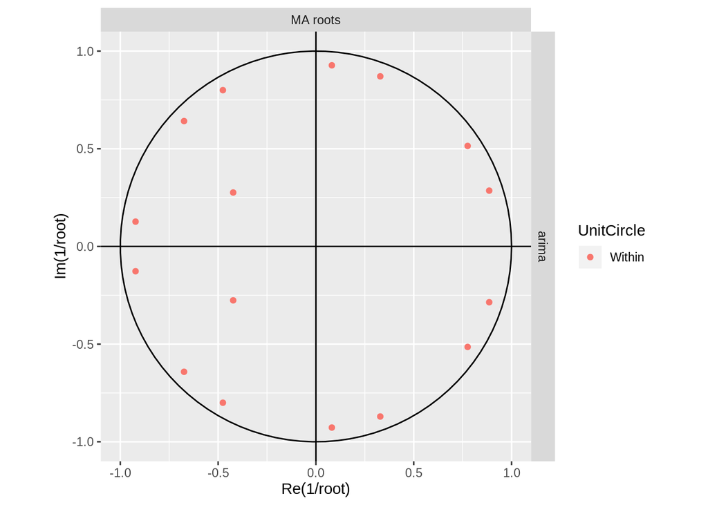

```r
gg_arma(fit)
```

Si mostramos los residuos vemos que aún no es un ruido blanco, aparecen picos que habría que evitar. Si observamos el gráfico ACF vemos que aún hay picos en retardos 14, 21, 28.. que hay que ajustar. Si observamos el gráfico PACF vemos que hay retardos en los mismos retardos con picos prácticamente.

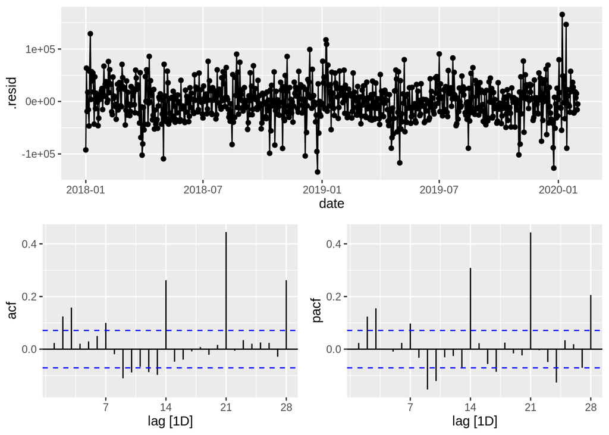

```r
fit %>% my_tsresiduals()
```

Forecast

```r
forecast_1 =  forecast(fit, h=10)
```

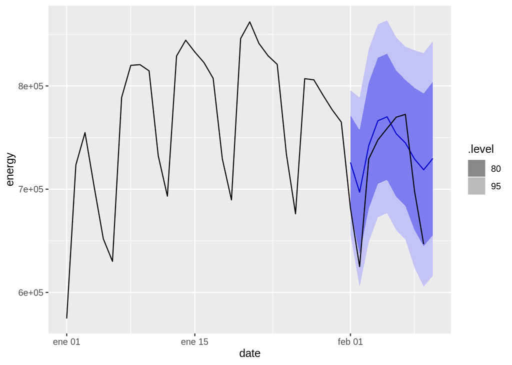

```r
# PLot forecast
#forecast %>% autoplot(df_demanda_train)
forecast_1 %>% autoplot(df_demanda%>% filter(date >= "2020-01-01"))
```

```r
# Residuals
mape(df_demanda_test$energy, forecast_1$energy)
```

```
## [1] 4.766615
```

```r
accuracy(forecast_1, df_demanda_test) #$energy
```

```
## # A tibble: 1 x 9
##   .model .type      ME   RMSE    MAE   MPE  MAPE  MASE   ACF1
##   <chr>  <chr>   <dbl>  <dbl>  <dbl> <dbl> <dbl> <dbl>  <dbl>
## 1 arima  Test  -19902. 39209. 32571. -3.11  4.77   NaN 0.0827
```

## Ajuste 2